# Case Study 9: Interacting with time

Etienne Beaulac

3/10/2018

## Time, XTS, Conversion

Here are the graphs that I created with dygraph and ggplot2. I feel like ggplot2 is more customizable, but there is a lot more speed to dygraphs.

### Here is my dygraph, and this is what I did to it

- I added red dashed lines to indicate the starting closing value of each ticker
- I added a zoom feature at the bottom
- I added a rounding feature that starts at 20 (if you want to see what the actual graph looks like, put 1)
- I added a crosshair to the cursor
- I added a fading effect depending on which ticker the mouse is hovering over
- I added a title

[interactive chart not shown]

```r
dygraph(tickers,
        main = "Stocks from select tickers over the past 5 years",
        ylab = "Close Price") %>%
  dyOptions(stepPlot = TRUE) %>%
  dyLimit(as.numeric(JCP[1,2]), color = "red") %>%  dyLimit(as.numeric(F[1,2]), color = "red") %>%
  dyLimit(as.numeric(CXW[1,2]), color = "red") %>%  dyLimit(as.numeric(GM[1,2]), color = "red") %>%
  dyLimit(as.numeric(KR[1,2]), color = "red") %>%   dyLimit(as.numeric(WDC[1,2]), color = "red") %>%
  dyLimit(as.numeric(NKE[1,2]), color = "red") %>%  dyLimit(as.numeric(T[1,2]), color = "red") %>%
  dyLimit(as.numeric(WDAY[1,2]), color = "red") %>% dyLimit(as.numeric(WFC[1,2]), color = "red") %>%
  dyLimit(as.numeric(WMT[1,2]), color = "red") %>%
  dySeries("JCP.Close", strokeWidth = 2, strokePattern = "dashed") %>%
  dySeries("F.Close", strokeWidth = 2, strokePattern = "dashed") %>%
  dySeries("CXW.Close", strokeWidth = 2, strokePattern = "dashed") %>%
  dyRangeSelector() %>%
  dyRoller(rollPeriod = 20) %>%
  dyUnzoom() %>%
  dyCrosshair(direction = "vertical") %>%
  dyHighlight(highlightCircleSize = 5,
              highlightSeriesBackgroundAlpha = 0.2,
              hideOnMouseOut = FALSE)
```

### My ggplot - A solid alternative

This plot is a pretty good source of pride for me. At first, I was thinking about simply reproducing my dygraph, but then I decided to add a little more, since some features are not available (dynamics).

- I tiddied the data
- I added a title & subtitle
- I changed unprofitable tickers to dashed lines
- I added horizontal pointed lines at the start of each ticker
- I added the title and total profit of each ticker at the far right

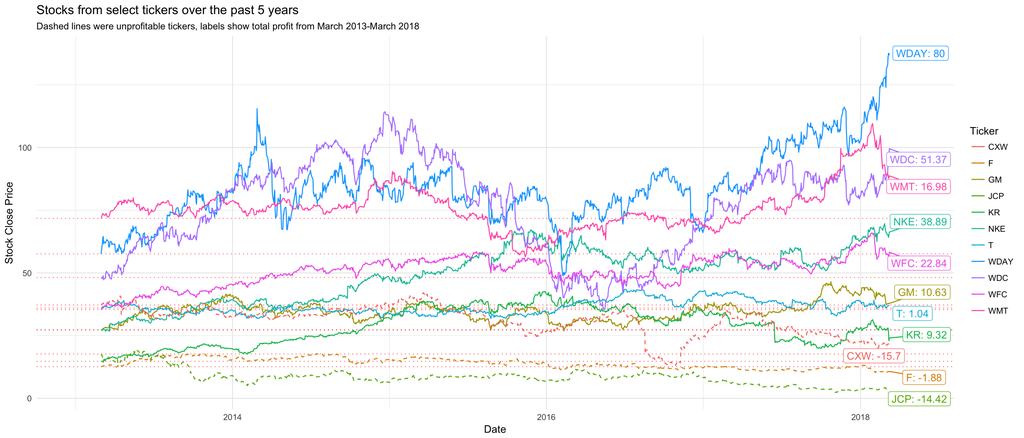

```r
df <- data.frame(date=index(tickers), coredata(tickers)) %>%
  gather("ticker", "close", 2:12) %>%
  mutate(ticker = gsub('.Close', '', ticker))

df <- df %>%
  group_by(ticker) %>%
  filter(date == "2018-03-09" | date == "2013-03-01") %>%
  summarize(profit = diff(close)) %>%
  ungroup() %>%
  mutate(status = case_when(profit >= 0 ~ 'good', profit < 0 ~ 'bad')) %>%
  right_join(df)

df %>%
  ggplot(aes(x = date, y = close, col = ticker)) +
  geom_hline(yintercept = as.vector((df %>%
                                       group_by(ticker) %>%
                                       slice(1) %>%
                                       ungroup() %>%
                                       select(close))$close),
             col = 'red',
             linetype = 'dotted',
             alpha = 0.5) +
  geom_line(data = df %>% filter(status == 'good')) +
  geom_line(data = df %>% filter(status == 'bad'), linetype = 'dashed') +
  geom_label_repel(data = df %>% filter(date == "2018-03-09"), show.legend = FALSE, aes(label = paste(ticker, profit, sep = ': ')), nudge_x = 30) +
  theme_minimal() +
  labs(y = 'Stock Close Price',
       x = 'Date',
       title = 'Stocks from select tickers over the past 5 years',
       col = 'Ticker',
       subtitle = 'Dashed lines were unprofitable tickers, labels show total profit from March 2013-March 2018') +
  scale_x_date(expand = c(0, 150)) +
  ggsave('Case_Study_09/analysis/plot.png', width = 15)
```